# Basic Hierarchical Models in RStanARM

Imad Ali

3/23/2017

## Introduction

This note is a brief introduction to the `stan_glmer()` function in [rstanarm](https://cran.r-project.org/web/packages/rstanarm/) which allows you to fit Bayesian hierarchical models. It is a good idea to use a hierarchical model if you believe that there is some sort of nested group structure in your data. For example, let $\mathbf{y}$ and $\mathbf{X}$ refer to the pooled outcome and predictor of your model, respectively. Now suppose that you can identify $J$ groups within your model so that $\{\mathbf{y}_j, \mathbf{X}_j\}$ refers to the data associated with the $j$th group. You have several options in terms of modeling, and we will discuss them below, after simulating the data.

## Simulating data

Below we simulate the data that will be used in the examples. For simplicity we consider only three groups (i.e. $J = 3$) and one predictor.

```r
# inverse logit function
invlogit <- function(x) {
  return(exp(x)/(1+exp(x)))
}
# coefficients generated from prior distributions
b10 <- rnorm(1,0,1)  # group 1 intercept
b11 <- rnorm(1,1,1)  # group 1 slope

b20 <- rnorm(1,0,1)  # group 2 intercept
b21 <- rnorm(1,1,1)  # group 2 slope

b30 <- rnorm(1,0,1)  # group 2 intercept
b31 <- rnorm(1,1,1)  # group 2 slope
# for ease of comparison post-estimation
parameters <- rbind("(Intercept)" = c(b10, b20, b30),
                    "x1" = c(b11, b21, b31))
colnames(parameters) <- c("model1", "model2", "model3")
# generate data
n <- 900
X <- data.frame(matrix(c(c(rep(1,n/3),rep(2,n/3),rep(3,n/3)),rnorm(n,0,1)),ncol = 2))
names(X) <- c("group","x1")
y1 <- invlogit(b10+b11*X[which(X$group==1),2])
y2 <- invlogit(b20+b21*X[which(X$group==2),2])
y3 <- invlogit(b30+b31*X[which(X$group==3),2])
y <- c(y1,y2,y3)
dat <- data.frame(cbind(rbinom(n,1,y),X))
names(dat)[1] <- "y"
head(dat)
```

```
##   y group          x1
## 1 1     1 -0.52534681
## 2 1     1  0.09934512
## 3 1     1  0.88661592
## 4 0     1  0.59462063
## 5 0     1 -1.22826941
## 6 0     1 -0.36789892
```

## Complete Pooling and No Pooling

If we **completely pool** the data then we are not taking into account the different groups. So we are modeling,
$$\mathbf{y} \sim \mbox{Bin}(1,\ \mbox{logit}^{-1}[\beta_0 + \mathbf{x}\beta])$$

The problem here is that we are *not accounting for group-specific variability*. (However, if there is no identifiable group structure then this may be an appropriate model.)

If there is **no pooling** of the data then we are modeling each group in separately. This means that we will have $J$ separate regression equations,
$$\begin{aligned}
\mathbf{y}_1 &\sim \mbox{Bin}(1,\ \mbox{logit}^{-1}[\beta_{0_1} + \mathbf{x}_1\beta_1]) \\
\mathbf{y}_2 &\sim \mbox{Bin}(1,\ \mbox{logit}^{-1}[\beta_{0_2} + \mathbf{x}_2\beta_2]) \\
&\vdots \\
\mathbf{y}_J &\sim \mbox{Bin}(1,\ \mbox{logit}^{-1}[\beta_{0_J} + \mathbf{x}_J\beta_J])
\end{aligned}$$

The problem here is that we are *not allowing the information used in one group to explain the model of another group*.

Using the data generated above we can estimate these two models using `stan_glm()`. The completely pooled model would be,

```r
fit1 <- stan_glm(y ~ x1, data = dat, family = binomial(link = "logit"),
                 cores = 4, iter = 500)
coef(fit1)
```

```
## (Intercept)          x1
##   0.2533957   0.4850910
```

The model (or models) with no pooling would be,

```r
fit2_1 <- stan_glm(y ~ x1, data = dat, family = binomial(link = "logit"),
                   subset = group == 1, cores = 4, iter = 500)
fit2_2 <- stan_glm(y ~ x1, data = dat, family = binomial(link = "logit"),
                   subset = group == 2, cores = 4, iter = 500)
fit2_3 <- stan_glm(y ~ x1, data = dat, family = binomial(link = "logit"),
                   subset = group == 3, cores = 4, iter = 500)
# compare parameter estimates
cbind("model1" = coef(fit2_1),
      "model2" = coef(fit2_2),
      "model3" = coef(fit2_3))
```

```
##                model1    model2     model3
## (Intercept) 0.1603537 -0.694283  1.1927149
## x1          0.7650611  1.634899 -0.5733866
```

```r
parameters
```

```
##                 model1    model2     model3
## (Intercept) 0.01385621 -0.481970  1.1964393
## x1          0.70846569  1.486828 -0.5269672
```

## Hierarchical Models

Bayesian hierarchical models provide an intermediate solution to the two extremes above. Most importantly, *these hierarchical models allow you to model group specific behavior while allowing interactions to exist across the groups*.

First a quick summary of the formula syntax for `stan_glmer` models:

- Recall that an intercept is included in the model by default so including `-1` anywhere in the `formula` will drop the intercept.
- The formula will consist of the standard expression you are familiar with in `stan_glm` (e.g. `y ~ x1 + x2 ...`), but now we have the option to nest observations. We denote a nested linear predictor within parentheses and a vertical bar: `(|)`. The formula for the linear predictor will be to the left of the vertical bar and the group structure will be identified to the right of the vertical bar.
- Consider the following formula: `y ~ x1 + (x1 - 1| group)`
  1. `x1` says to model an overall intercept and a slope parameter for the variable `x1`
  2. `(x1 - 1| group)` says that within each group model a slope parameter that feeds into the overall slope paremeter in (1).

### Varying Intercept

Here we want the intercept for each group to vary but the slopes will remain constant across the groups. Our model might look like,
$$\begin{aligned}
\mathbf{y}_1 &\sim \mbox{Bin}\bigg(1,\ \mbox{logit}^{-1}[\beta_{0_1} + \mathbf{x}\beta]\bigg) \\
\mathbf{y}_2 &\sim \mbox{Bin}\bigg(1,\ \mbox{logit}^{-1}[\beta_{0_2} + \mathbf{x}\beta]\bigg) \\
&\vdots \\
\mathbf{y}_J &\sim \mbox{Bin}\bigg(1,\ \mbox{logit}^{-1}[\beta_{0_J} + \mathbf{x}\beta]\bigg) \\
\beta &\sim \mathcal{N}(0, 2.5) \\
\boldsymbol{\beta_{0}} &\sim \mathcal{N}(\mu_0, 1) \\
\mu_0 &\sim \mathcal{N}(0, 10)
\end{aligned}$$

where $\beta_{0j}$ refers to the intercept of the $j$th group and $\mu_0$ is the overall intercept.

We can fit the model using `stan_glmer()` as follows,

```r
fit3 <- stan_glmer(y ~ x1 + (1 | group), data = dat, family = binomial(link = "logit"),
                   cores = 4, iter = 500)
summary(fit3)
```

```
##
## Model Info:
##
##  function:  stan_glmer
##  family:    binomial [logit]
##  formula:   y ~ x1 + (1 | group)
##  algorithm: sampling
##  priors:    see help('prior_summary')
##  sample:    1000 (posterior sample size)
##  num obs:   900
##  groups:    group (3)
##
## Estimates:
##                                        mean   sd     2.5%   25%    50%
## (Intercept)                             0.3    0.7   -1.2    0.0    0.3
## x1                                      0.5    0.1    0.4    0.5    0.5
## b[(Intercept) group:1]                 -0.2    0.7   -1.7   -0.5   -0.2
## b[(Intercept) group:2]                 -0.8    0.7   -2.4   -1.2   -0.8
## b[(Intercept) group:3]                  0.9    0.7   -0.6    0.5    0.9
## Sigma[group:(Intercept),(Intercept)]    1.7    2.5    0.2    0.5    0.9
## mean_PPD                                0.6    0.0    0.5    0.5    0.6
## log-posterior                        -555.3    1.9 -559.9 -556.4 -554.9
##                                        75%    97.5%
## (Intercept)                             0.7    1.9
## x1                                      0.6    0.7
## b[(Intercept) group:1]                  0.2    1.3
## b[(Intercept) group:2]                 -0.4    0.7
## b[(Intercept) group:3]                  1.3    2.4
## Sigma[group:(Intercept),(Intercept)]    1.8    8.7
## mean_PPD                                0.6    0.6
## log-posterior                        -553.8 -552.4
##
## Diagnostics:
##                                      mcse Rhat n_eff
## (Intercept)                          0.0  1.0   287
## x1                                   0.0  1.0   581
## b[(Intercept) group:1]               0.0  1.0   290
## b[(Intercept) group:2]               0.0  1.0   291
## b[(Intercept) group:3]               0.0  1.0   290
## Sigma[group:(Intercept),(Intercept)] 0.1  1.0   320
## mean_PPD                             0.0  1.0  1000
## log-posterior                        0.1  1.0   405
##
## For each parameter, mcse is Monte Carlo standard error, n_eff is a crude measure of effective sample size, and Rhat is the potential scale reduction factor on split chains (at convergence Rhat=1).
```

We should take a look at the traceplots to confirm that our chains have mixed well.

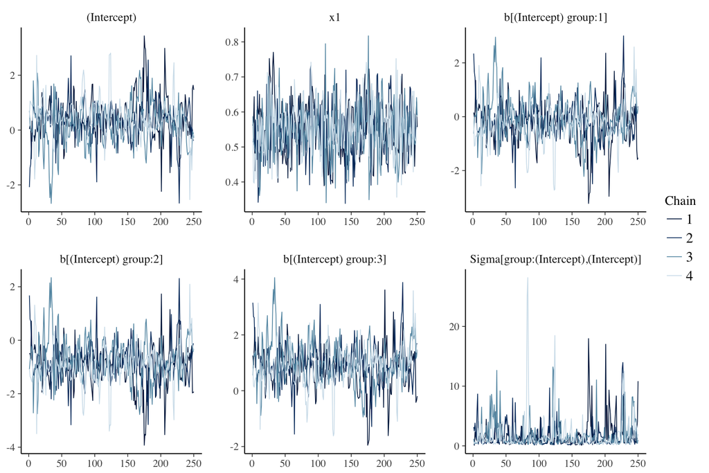

```r
plot(fit3, plotfun = "trace")
```

We can have a look at the group-specific deviations (`ranef()`) from the overall parameter values (`fixef()`).

```r
ranef(fit3)
```

```
## $group
##   (Intercept)
## 1  -0.1619844
## 2  -0.8255727
## 3   0.9096786
```

```r
fixef(fit3)
```

```
## (Intercept)          x1
##   0.3194038   0.5476766
```

We can also look at the group-specific parameters (`coef()`)

```r
coef(fit3)
```

```
## $group
##   (Intercept)        x1
## 1   0.1574194 0.5476766
## 2  -0.5061689 0.5476766
## 3   1.2290824 0.5476766
##
## attr(,"class")
## [1] "coef.mer"
```

Note that `coef()` is the group-wise sum of `ranef()` and `fixef()`

```r
ranef(fit3)$group["(Intercept)"] + fixef(fit3)["(Intercept)"]
```

```
##   (Intercept)
## 1   0.1574194
## 2  -0.5061689
## 3   1.2290824
```

### Varying Slope

Here we want the slope to vary for each group while keeping the group-specific intercepts constant. Our model might look like,
$$\begin{aligned}
\mathbf{y}_1 &\sim \mbox{Bin}\bigg(1,\ \mbox{logit}^{-1}[\beta_{0} + \mathbf{x}_{1}\beta_{1}]\bigg) \\
\mathbf{y}_2 &\sim \mbox{Bin}\bigg(1,\ \mbox{logit}^{-1}[\beta_{0} + \mathbf{x}_{2}\beta_{2}]\bigg) \\
&\vdots \\
\mathbf{y}_J &\sim \mbox{Bin}\bigg(1,\ \mbox{logit}^{-1}[\beta_{0} + \mathbf{x}_{J}\beta_{J}]\bigg) \\
\beta_0 &\sim \mathcal{N}(0,10) \\
\boldsymbol{\beta} &\sim \mathcal{N}(\mu, 1) \\
\mu &\sim \mathcal{N}(0, 2.5)
\end{aligned}$$

where $\mu$ is the overall slope parameter.

We can fit the model using `stan_glmer()` as follows,

```r
fit4 <- stan_glmer(y ~ x1 + (x1 - 1 | group), data = dat, family = binomial(link = "logit"),
                   cores = 4, iter = 500)
summary(fit4)
```

```
##
## Model Info:
##
##  function:  stan_glmer
##  family:    binomial [logit]
##  formula:   y ~ x1 + (x1 - 1 | group)
##  algorithm: sampling
##  priors:    see help('prior_summary')
##  sample:    1000 (posterior sample size)
##  num obs:   900
##  groups:    group (3)
##
## Estimates:
##                      mean   sd     2.5%   25%    50%    75%    97.5%
## (Intercept)           0.3    0.1    0.1    0.2    0.3    0.3    0.4
## x1                    0.6    0.7   -0.7    0.2    0.6    1.0    2.0
## b[x1 group:1]         0.2    0.7   -1.3   -0.2    0.2    0.6    1.5
## b[x1 group:2]         1.0    0.7   -0.5    0.6    1.0    1.4    2.3
## b[x1 group:3]        -1.1    0.7   -2.5   -1.5   -1.0   -0.7    0.3
## Sigma[group:x1,x1]    1.9    2.3    0.3    0.7    1.2    2.2    8.1
## mean_PPD              0.6    0.0    0.5    0.5    0.6    0.6    0.6
## log-posterior      -549.1    1.9 -553.3 -550.1 -548.7 -547.6 -546.3
##
## Diagnostics:
##                    mcse Rhat n_eff
## (Intercept)        0.0  1.0  1000
## x1                 0.0  1.0   292
## b[x1 group:1]      0.0  1.0   299
## b[x1 group:2]      0.0  1.0   293
## b[x1 group:3]      0.0  1.0   300
## Sigma[group:x1,x1] 0.1  1.0   450
## mean_PPD           0.0  1.0  1000
## log-posterior      0.1  1.0   229
##
## For each parameter, mcse is Monte Carlo standard error, n_eff is a crude measure of effective sample size, and Rhat is the potential scale reduction factor on split chains (at convergence Rhat=1).
```

Examine the traceplots.

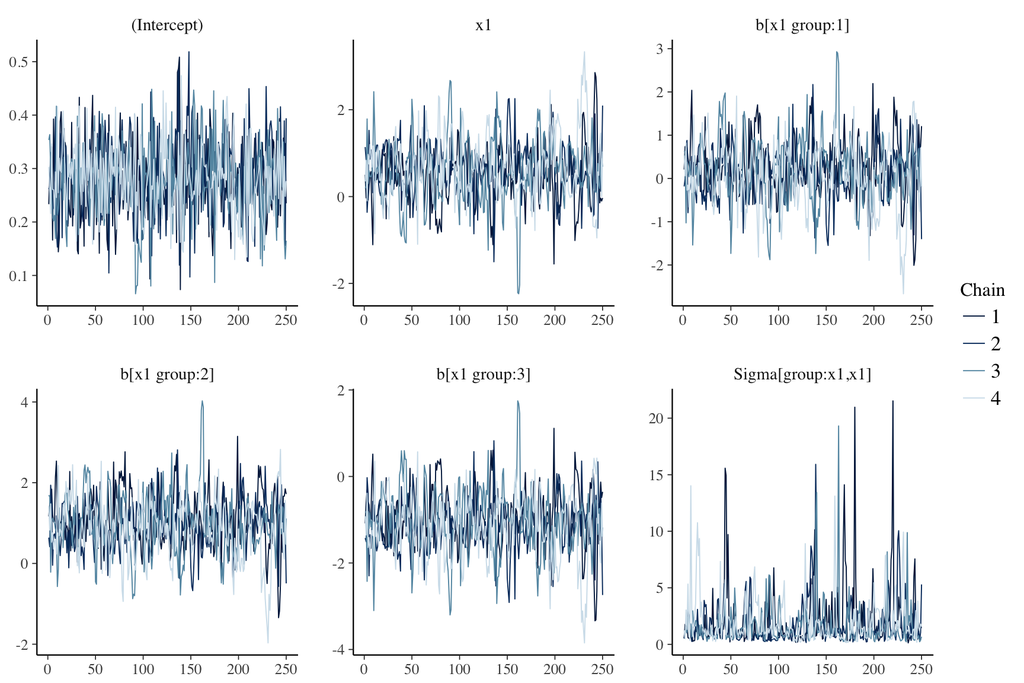

```r
plot(fit4, plotfun = "trace")
```

Have a look at the overall and group-specific parameters

```r
fixef(fit4)
```

```
## (Intercept)          x1
##   0.2818653   0.5914591
```

```r
coef(fit4)
```

```
## $group
##   (Intercept)         x1
## 1   0.2818653  0.7573600
## 2   0.2818653  1.5680393
## 3   0.2818653 -0.4521339
##
## attr(,"class")
## [1] "coef.mer"
```

### Varying Intercept and Slope

We can fit the model using `stan_glmer()` as follows,

```r
fit5 <- stan_glmer(y ~ x1 + (x1 | group), data = dat, family = binomial(link = "logit"),
                   cores = 4, iter = 500)
```

Examine the traceplots.

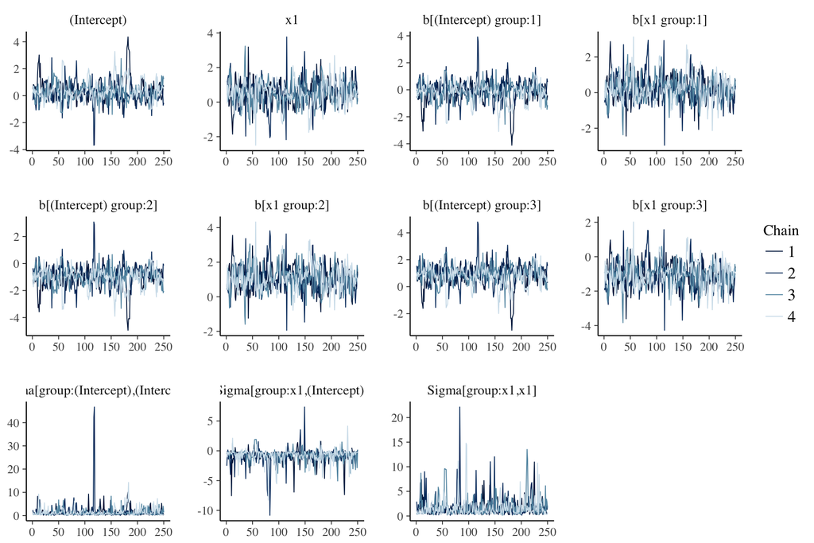

```r
plot(fit5, plotfun = "trace")
```

Have a look at the overall and group-specific parameters

```r
fixef(fit5)
```

```
## (Intercept)          x1
##   0.2485661   0.5376956
```

```r
coef(fit5)
```

```
## $group
##   (Intercept)         x1
## 1   0.1792064  0.7415392
## 2  -0.6746397  1.5691685
## 3   1.1693606 -0.5685042
##
## attr(,"class")
## [1] "coef.mer"
```

## Deeper Hierarchial Models

By no means are the following models deep, however, introducing a new grouping variable (despite being spurious) helps us identify more models that we can specify with `stan_glmer()`.

First we indtroduce a second grouping variable `group2` which includes two groups within each group of `group`.

```r
dat$group2 <- c(rep(1,150),rep(2,150),rep(3,150),rep(4,150),rep(5,150),rep(6,150))
dat[140:160,]
```

```
##     y group         x1 group2
## 140 1     1  0.1571922      1
## 141 1     1 -0.6986514      1
## 142 1     1 -0.7620608      1
## 143 1     1  0.6285432      1
## 144 1     1  0.8903852      1
## 145 1     1  0.0219100      1
## 146 1     1  1.4036954      1
## 147 0     1 -0.6836530      1
## 148 1     1  1.8846087      1
## 149 0     1 -0.4888928      1
## 150 1     1  0.3999729      1
## 151 0     1 -1.2253621      2
## 152 0     1 -0.8477653      2
## 153 1     1  1.1137999      2
## 154 1     1  0.1784220      2
## 155 1     1 -1.1751302      2
## 156 1     1 -0.5240504      2
## 157 0     1 -0.1423131      2
## 158 1     1  0.4900928      2
## 159 0     1  0.7722149      2
## 160 1     1  1.5597707      2
```

In the model we fit below, the new term `group:group2` is saying to estimate `group2` specific parameters where the subgroups of `group` are `group2`.

So we are estimating a total of $2 + 6 + 12 = 20$ parameters.

```r
fit6 <- stan_glmer(y ~ x1 + (x1 | group) + (x1 | group:group2), data = dat, family = binomial(link = "logit"),
                   cores = 4, iter = 500)
summary(fit6)
```

```
##
## Model Info:
##
##  function:  stan_glmer
##  family:    binomial [logit]
##  formula:   y ~ x1 + (x1 | group) + (x1 | group:group2)
##  algorithm: sampling
##  priors:    see help('prior_summary')
##  sample:    1000 (posterior sample size)
##  num obs:   900
##  groups:    group:group2 (6), group (3)
##
## Estimates:
##                                               mean   sd     2.5%   25%
## (Intercept)                                    0.2    0.7   -1.1   -0.1
## x1                                             0.6    0.7   -1.0    0.2
## b[(Intercept) group:group2:1:1]                0.0    0.1   -0.4   -0.1
## b[x1 group:group2:1:1]                         0.0    0.1   -0.3    0.0
## b[(Intercept) group:group2:1:2]                0.0    0.1   -0.2    0.0
## b[x1 group:group2:1:2]                         0.0    0.1   -0.3    0.0
## b[(Intercept) group:group2:2:3]                0.0    0.2   -0.5   -0.1
## b[x1 group:group2:2:3]                         0.1    0.2   -0.2    0.0
## b[(Intercept) group:group2:2:4]                0.0    0.2   -0.4    0.0
## b[x1 group:group2:2:4]                         0.0    0.2   -0.3   -0.1
## b[(Intercept) group:group2:3:5]                0.0    0.2   -0.3   -0.1
## b[x1 group:group2:3:5]                         0.0    0.2   -0.5    0.0
## b[(Intercept) group:group2:3:6]                0.1    0.2   -0.2    0.0
## b[x1 group:group2:3:6]                        -0.1    0.3   -0.9   -0.1
## b[(Intercept) group:1]                        -0.1    0.7   -1.4   -0.4
## b[x1 group:1]                                  0.1    0.7   -1.2   -0.3
## b[(Intercept) group:2]                        -0.9    0.7   -2.3   -1.2
## b[x1 group:2]                                  1.0    0.7   -0.3    0.5
## b[(Intercept) group:3]                         0.9    0.7   -0.4    0.6
## b[x1 group:3]                                 -1.1    0.7   -2.6   -1.6
## Sigma[group:group2:(Intercept),(Intercept)]    0.0    0.1    0.0    0.0
## Sigma[group:group2:x1,(Intercept)]             0.0    0.1   -0.1    0.0
## Sigma[group:group2:x1,x1]                      0.0    0.2    0.0    0.0
## Sigma[group:(Intercept),(Intercept)]           1.5    2.0    0.2    0.5
## Sigma[group:x1,(Intercept)]                   -0.8    1.5   -3.6   -1.1
## Sigma[group:x1,x1]                             1.8    2.1    0.2    0.6
```

[output cut: 49 more lines]

```
## b[x1 group:1]                               0.0  1.0   468
## b[(Intercept) group:2]                      0.0  1.0   333
## b[x1 group:2]                               0.0  1.0   475
## b[(Intercept) group:3]                      0.0  1.0   308
## b[x1 group:3]                               0.0  1.0   387
## Sigma[group:group2:(Intercept),(Intercept)] 0.0  1.0   223
## Sigma[group:group2:x1,(Intercept)]          0.0  1.0   156
## Sigma[group:group2:x1,x1]                   0.0  1.0   183
## Sigma[group:(Intercept),(Intercept)]        0.1  1.0   587
## Sigma[group:x1,(Intercept)]                 0.1  1.0   574
## Sigma[group:x1,x1]                          0.1  1.0   666
## mean_PPD                                    0.0  1.0   845
## log-posterior                               0.3  1.0   330
##
## For each parameter, mcse is Monte Carlo standard error, n_eff is a crude measure of effective sample size, and Rhat is the potential scale reduction factor on split chains (at convergence Rhat=1).
```

```r
fixef(fit6)
```

```
## (Intercept)          x1
##   0.2147201   0.6211562
```

```r
ranef(fit6)
```

```
## $`group:group2`
##       (Intercept)            x1
## 1:1 -0.0094944059 -0.0003073132
## 1:2  0.0115725848  0.0012269343
## 2:3 -0.0034583664  0.0112306982
## 2:4 -0.0001543056 -0.0015165935
## 3:5 -0.0074177346  0.0035903720
## 3:6  0.0175314989 -0.0196452689
##
## $group
##   (Intercept)         x1
## 1 -0.06112083  0.1196754
## 2 -0.86292912  0.9668524
## 3  0.91836963 -1.1298708
```

```r
coef(fit6)
```

```
## $`group:group2`
##     (Intercept)        x1
## 1:1   0.2052257 0.6208489
## 1:2   0.2262927 0.6223831
## 2:3   0.2112617 0.6323869
## 2:4   0.2145658 0.6196396
## 3:5   0.2073024 0.6247465
## 3:6   0.2322516 0.6015109
##
## $group
##   (Intercept)         x1
## 1   0.1535993  0.7408315
## 2  -0.6482090  1.5880086
## 3   1.1330897 -0.5087146
##
## attr(,"class")
## [1] "coef.mer"
```